# STAT 361 - RECITATION 9

# Topic : Bootstrap and Jackknife

### İrem Tanrıverdi, iremt@metu.edu.tr

### Date: 02.06.2022

## REVIEW !

Assume in a dataset, we observe n values, denoted as $X_1, · · · , X_n$. For simplicity, we assume that these observations are an IID (indenpendently, identically distributed) random sample from an unknown distribution function F(x).

Because these n values are random, any statistic derived from them will also be random. For instance, let M be the median of these n values (sample median). **The value of the median will be determined by these n observations.**

Because these observations are a random sample from the distribution F , **the median will also be random, and it will have its own distribution (also depends on F but through a more complicated way)!**

Let assume the distribution is something we know, say a standard Normal distribution N(0,1), and the sample size n = 100. What will the distribution of the sample median be?

We can find this out using the Monte Carlo Simulation approach. First we draw a random sample using R and compute the sample median:

```r
X = rnorm(100)
X_med = median(X)
X_med
```

-0.122997663538001

This gives us one realization of the median. However, every time we apply the same program, we obtain a different value of the sample median because of a different sets of points we are having.

One way to investigate the distribution of sample median is to repeat the above procedure many times and keep track of the sample median of each sample we generate.

```r
N = 10000 # number of repitions

many_median = rep(NA, N)

for(i in 1:N){
    X = rnorm(100)
    X_med = median(X)
    many_median[i] = X_med # save the median in each repitition
}

head(many_median) # contains the 10000 realizations of the sample median
```

1. 0.156345566266006

2. 0.0769538846937099

3. 0.0032409272334042

4. -0.0545628197618408

5. -0.185472410810995

6. 0.231460044684206

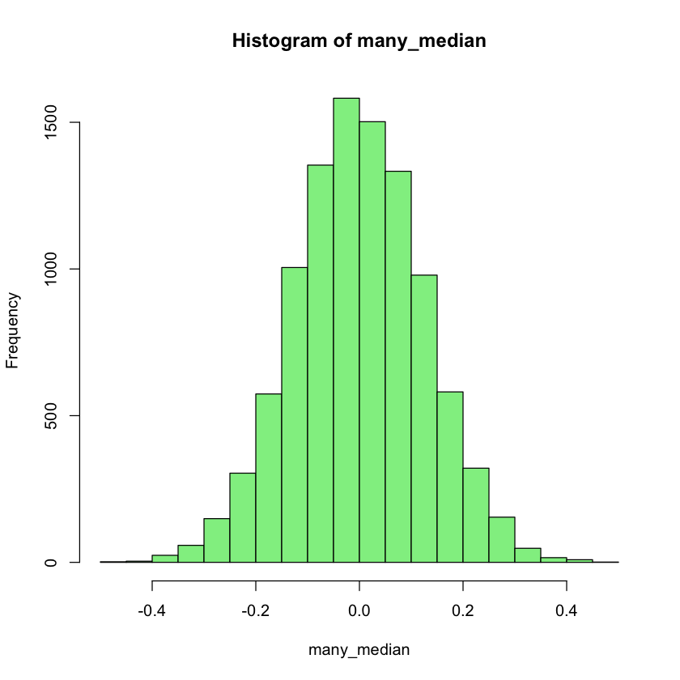

```r
hist(many_median, col="lightgreen")
```

- The sample median also seems roughly a Normal distribution.

The above method we are using is call Monte Carlo Simulation to investigate the distribution of something, instead of using mathematics to derive it, we use computer experiments to obtain an approximated answer to the problem.

- The number of repition N: sometimes called the size of Monte Carlo Simulation and it controls the error of the simulation (this type of error is called Monte Carlo errors). Similar to the sample size, a large repition N we are using, a smaller Monte Carlo error we have.

# BOOTSTRAP

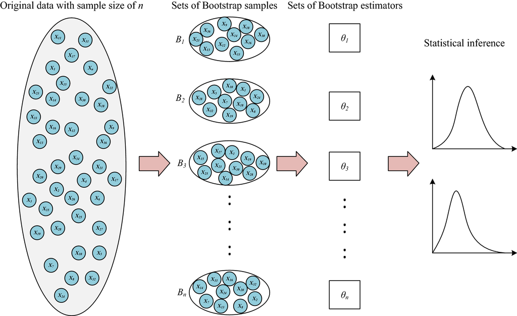

The bootstrap is a method of Monte Carlo simulation where no parametric assumptions are made about the underlying population that generated the random sample.

Bootstrap methods are often used when the distribution of the target population is not specified; the sample is the only information available.

### The bootstrap is a Monte Carlo Simulation approach based on the data we haveto estimate the uncertainty of a statistic or an estimator. A powerful feature of the bootstrap is: we do not need to know the true distribution.

Take the median for an example. How do we estimate its distribution or uncertainty (say variance)? We generate the same size of data from the same distribution many times and then use the histogram, variance of these new realizations.

We use the sample as an estimate of the population. This estimate is called the emprical distribution $\hat F$ where each $x_i$ has probability mass $\frac{1}{n}$. Thus, each $x_i$ has the same likelihood of being selected in the new sample from $\hat F$.

When we use $\hat F$ as our pseudo-population, then we resample with replacement from the original sample.

To get an idea about the distribution of desired statistic, we obtain B bootstrap samples by sampling with replacement from the original sample.

Then calculate this statistic for each bootstrap sample. Then, these bootstrap replicates provide us with an estimate of the distribution of desired statistic.

## Procedure

1. Given a random sample, $x = (x_1,x_2,...,x_n)$, calculate $\hat{\theta}$.
2. Sample with replacement from the original sample to get $x^{*^b} = (x_1^{*^b},x_2^{*^b},...,x_n^{*^b})$
3. Calculate the same statistic using the bootstrap sample in step 2 to get $\hat{\theta}^{*}_b$.
4. Repeat steps 2 through 3, B times.
5. Use this estimate of the distribution of $\hat{\theta}$ (i.e.the bootstrap replicates, $\hat{\theta}^{*}_b$) to obtain the desired characteristic (eg. standard error, bias or confidence interval).

Standard error of $\hat{\theta}$ is calculated by $$ \hat{SE}_B(\hat{\theta}) = \sqrt{\frac{1}{B-1} \sum_{b=1}^B(\hat{\theta}^{*}_b-\bar{\hat{\theta^*}})^2} $$ where $\bar{\hat{\theta^*}} = \frac{1}{B} \sum_{b=1}^B\hat{\theta}^{*}_b$

Estimate the bias of $\hat{\theta}$ is calculated by

$$ \textrm{bias}(T) = E(T) - \theta $$$$ \hat{\textrm{bias}_B} = \bar{\hat{\theta}^*} - \hat{\theta} $$

Here is one example of applying the bootstrap to approximate the uncertainty of sample median of the variable eruptions in the faithful data:

```r
head(faithful)
```

| eruptions | waiting |
| --- | --- |
| 3.600 | 79 |
| 1.800 | 54 |
| 3.333 | 74 |
| 2.283 | 62 |
| 4.533 | 85 |
| 2.883 | 55 |

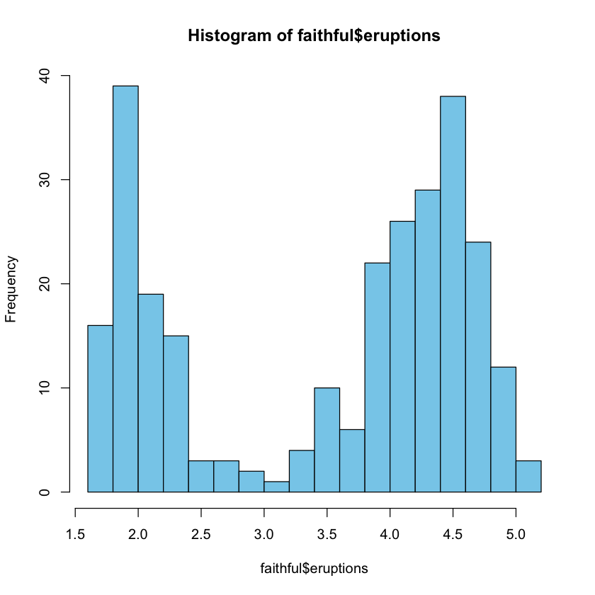

```r
hist(faithful$eruptions, breaks=20, col="skyblue")
```

```r
median(faithful$eruptions)
```

4

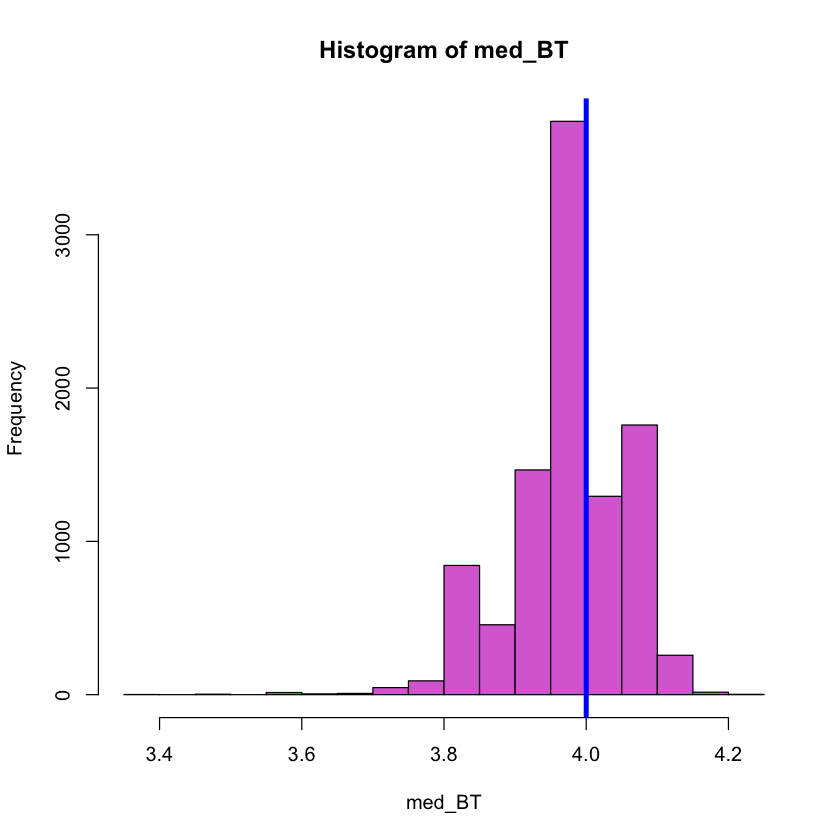

```r
# this gives us the sample median of 'eruptions'

M = 10000 # size of Monte Carlo Simulation

med_BT = rep(NA, M)
n = nrow(faithful)

for(i in 1:M){

    w = sample(n,n, replace=T) # this generates the indices we are selecting during the sample with replacement
    X_BT = faithful$eruptions[w]
    med_BT[i] = median(X_BT)

}

hist(med_BT, col="orchid") # an approximated distribution of sample median
abline(v=median(faithful$eruptions), col="blue",lwd=4)
```

```r
# an approximated variance of sample median

var(med_BT)
```

0.00639593049434694

The command w = sample(n,n, replace=T) generates indices that are IID from a uniform distribution over 1, 2, 3, ..., n. Thus, the command ${faithful$eruptions[w]}$ selects those observations being selected and it is then a sample with replacement from the original data faithful$eruptions.

Moreover, because we know that the sample median (under suitable conditions) follows roughly a Normal distribution. We can then construct a 90% confidence interval using

```r
upper <- median(faithful$eruptions) + qnorm(0.95)*sd(med_BT)
lower <- median(faithful$eruptions) - qnorm(0.95)*sd(med_BT)

cat("90% confidence interval for eruptions is= (", lower, ",", upper, ")")
```

```
90% confidence interval for eruptions is= ( 3.868454 , 4.131546 )
```

**Sample correlation**

The bootstrap can also be applied to estimate the uncertainty of a statistic of values of two variables such as the sample correlation. Here is one example using the faithful data again.

```r
cor(faithful)
```

|  | eruptions | waiting |
| --- | --- | --- |
| eruptions | 1.0000000 | 0.9008112 |
| waiting | 0.9008112 | 1.0000000 |

```
[1] 0.9010843
```

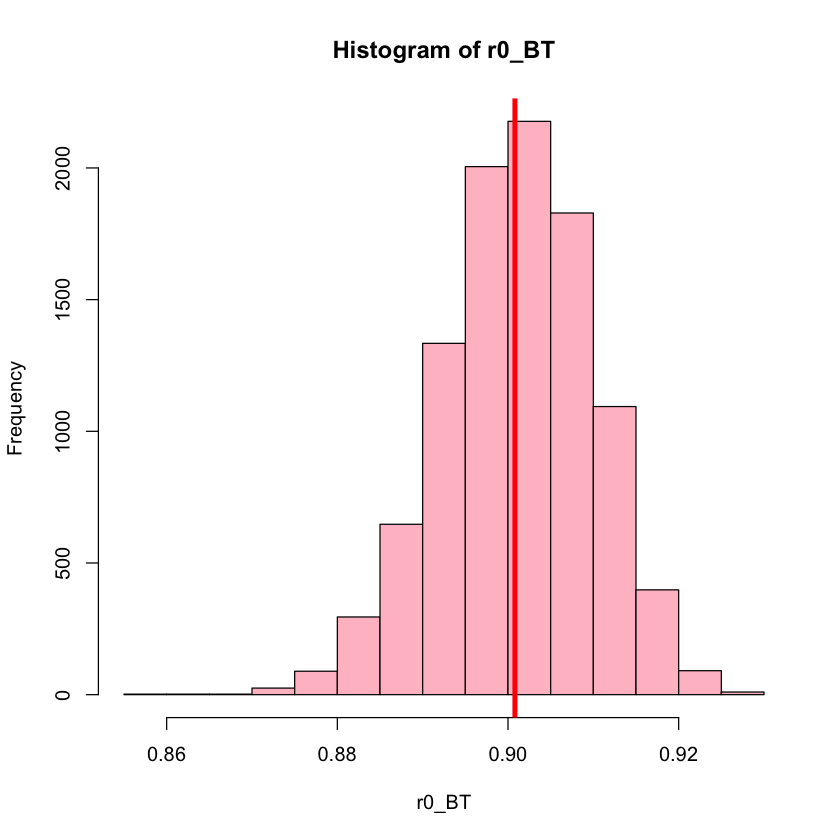

```r
set.seed(361)

# this returns a sample correlation matrix
r0 = cor(faithful)[1,2] # this is the correlation between the two variables

n = nrow(faithful)
B = 10000

r0_BT = rep(NA, B)

for(i in 1:B){
    w = sample(n,n,replace=T)
    faithful_BT = faithful[w,]
    r0_BT[i] = cor(faithful_BT)[1,2]

}

estimated_cor <- mean(r0_BT)
print(estimated_cor)

hist(r0_BT, col="pink") # the distribution from the bootstrap
abline(v=r0, col="red",lwd=4)
```

```r
var(r0_BT) # the estimated variance
```

7.83997204050567e-05

```r
upper <- estimated_cor+qnorm(0.90)*sd(r0_BT)
lower <- estimated_cor-qnorm(0.90)*sd(r0_BT)

cat("90% confidence interval for eruptions is= (", lower, ",", upper, ")")
```

[output not shown]

## Q1)

Now we will consider the dataset iris. We focus on the variable Sepal.Length.

- What is the sample Standard deviation of this variable?
- Use the bootstrap to show the distribution of the sample Standard deviation.
- What is the standard error and bias of the sample Standard deviation computed using the bootstrap?
- Find a 90% CI of the sample SD.
- Find the variance of the estimator.

```r
data("iris")
head(iris)
```

| Sepal.Length | Sepal.Width | Petal.Length | Petal.Width | Species |
| --- | --- | --- | --- | --- |
| 5.1 | 3.5 | 1.4 | 0.2 | setosa |
| 4.9 | 3.0 | 1.4 | 0.2 | setosa |
| 4.7 | 3.2 | 1.3 | 0.2 | setosa |
| 4.6 | 3.1 | 1.5 | 0.2 | setosa |
| 5.0 | 3.6 | 1.4 | 0.2 | setosa |
| 5.4 | 3.9 | 1.7 | 0.4 | setosa |

```r
sd(iris$Sepal.Length) # sample Standard deviation is 0.82
```

0.828066127977863

**sample sd**

0.828066127977863

**estimated sd**

0.824284123628904

**std.error**

0.0403980431294141

**bias**

-0.00378200434895892

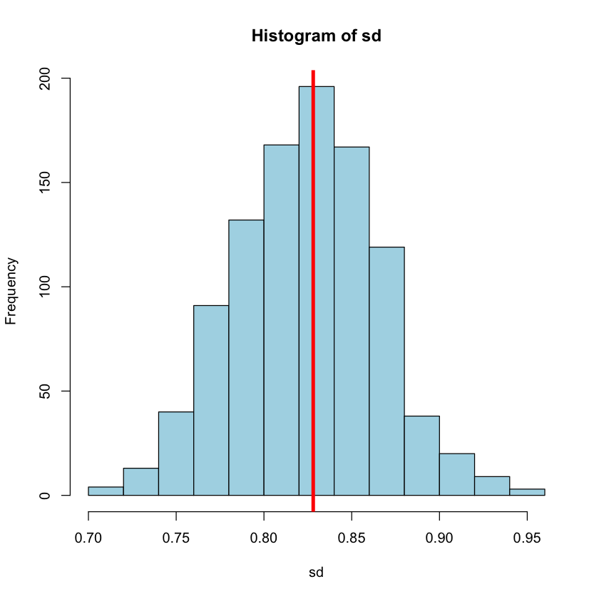

```r
B <- 1000 # bootstrap replicates

sd <- numeric(B)

sample_sd <- sd(iris$Sepal.Length)

for(i in 1:B){
    index <- sample(1:nrow(iris), size = nrow(iris),replace = TRUE)
    x <- iris[index,"Sepal.Length"]
    sd[i] <- sd(x)
}

est_sd <- mean(sd)
se_sd <- sd(sd)
bias_sd <- est_sd - sample_sd


hist(sd, col="lightblue") # the distribution from the bootstrap
abline(v=sample_sd, col="red",lwd=4)



out <- c(sample_sd, est_sd, se_sd, bias_sd)
names(out) <- c("sample sd", "estimated sd", "std.error", "bias")
out
```

```r
upper <- est_sd + qnorm(0.90) * se_sd
lower <- est_sd - qnorm(0.90) * se_sd

cat("90% confidence interval for eruptions is= (", lower, ",", upper, ")")
```

[output not shown]

## BOOT FUNCTION

```r
library(boot)

sd <- function(x,i){
  n <- length(x)
  sample_sd <- sqrt((sum((x[i] - mean(x[i]))^2))/n)
}



obj <- boot(data=iris$Sepal.Length, statistic = sd, R=1000)
obj
```

```
ORDINARY NONPARAMETRIC BOOTSTRAP


Call:
boot(data = iris$Sepal.Length, statistic = sd, R = 1000)


Bootstrap Statistics :
     original       bias    std. error
t1* 0.8253013 -0.004340878  0.04097882
```

## Q2)

We focus on the variable Sepal.Width.

- What is the sample skewness of this variable?
- Use the bootstrap to show the distribution of the sample skewness.
- What is the standard error and bias of the sample skewness computed using the bootstrap?
- Find a 90% CI of the sample skewness.

**sample**

0.312614703922861

**estimated**

0.314138208493596

**std.error**

0.174753449332121

**bias**

0.00152350457073486

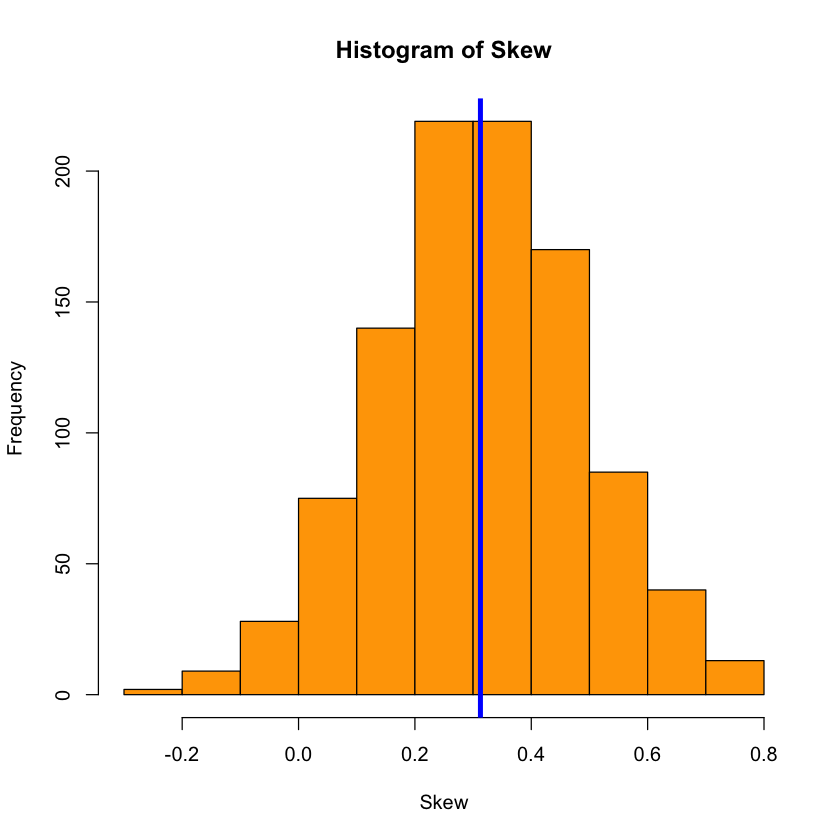

```r
library(e1071)

set.seed(123)

B <- 1000
sample_skew <- skewness(iris$Sepal.Width)
Skew <-c()

for(i in 1:B){
    index <- sample(1:nrow(iris), size = nrow(iris),replace = TRUE)
    x <- iris[index,"Sepal.Width"]
    Skew[i] <- skewness(x)
}

est_skew <- mean(Skew)
se_skew <- sd(Skew)
bias_skew <- est_skew - sample_skew

out <- c(sample_skew, est_skew, se_skew, bias_skew)
names(out) <- c("sample", "estimated", "std.error", "bias")
out


hist(Skew, col="orange") # the distribution from the bootstrap
abline(v=sample_skew, col="blue",lwd=4)
```

### Skewness is a statistical numerical method to measure the asymmetry of the distribution or data set. It tells about the position of the majority of data values in the distribution around the mean value.

### Skewness formula:

# $S = \frac{\frac{1}{n} \sum_{i=1}^n(x_i - \bar x)^3}{(\frac{1}{n} \sum_{i=1}^n(x_i - \bar x)^2)^{3/2}}$

```r
library(boot)

skew <- function(x,i){
    n <- length(x)
    sample_skw <- mean((x[i] - mean(x[i]))^3) / mean((x[i] - mean(x[i]))^2)^(3/2)
    return(sample_skw)

}

obj <- boot(data=iris$Sepal.Width, statistic = skew, R=1000)
obj
```

```
ORDINARY NONPARAMETRIC BOOTSTRAP


Call:
boot(data = iris$Sepal.Width, statistic = skew, R = 1000)


Bootstrap Statistics :
     original      bias    std. error
t1* 0.3157671 -0.01708328   0.1856983
```

```r
upper <- est_skew + qnorm(0.95) * se_skew
lower <- est_skew - qnorm(0.95) * se_skew

cat("95% confidence interval for eruptions is= (", lower, ",", upper, ")")
```

[output not shown]

## Q3)

```r
shapiro.test(iris$Sepal.Width)
```

```
	Shapiro-Wilk normality test

data:  iris$Sepal.Width
W = 0.98492, p-value = 0.1012
```

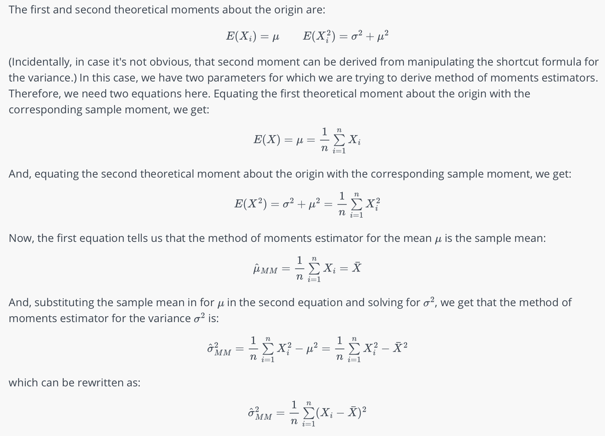

```r
n <- length(iris$Sepal.Width)

sigma.hat <- sum((iris$Sepal.Width - mean(iris$Sepal.Width))^2) / n

B <- 1000
sigma.boot <- numeric(B)

for(i in 1:B){
    index <- sample(n, size=n, replace = T)
    sigma.boot[i] <- sum((iris$Sepal.Width[index] - mean(iris$Sepal.Width[index]))^2) / n
}

estimate.sigma <- mean(sigma.boot)
SE <- sd(sigma.boot)

bias <- estimate.sigma - sigma.hat
out <- c(sigma.hat, estimate.sigma, SE, bias)
names(out) <- c("sigma.hat","estimated sigma", "Std.Err", "Bias")
out
```

**sigma.hat**

0.188712888888889

**estimated sigma**

0.186981410666667

**Std.Err**

0.022110354909377

**Bias**

-0.00173147822222225

## Q4)

Now we will consider the dataset mtcars. We focus on the variables disp and hp.

- What is the correlation between these variable?
- Use the bootstrap to show the distribution of the sample correlation.
- What is the standard error and bias of the sample correlation computed using the bootstrap?
- Find a 95% CI of the sample correlation.

```r
head(mtcars)
```

|  | mpg | cyl | disp | hp | drat | wt | qsec | vs | am | gear | carb |
| --- | --- | --- | --- | --- | --- | --- | --- | --- | --- | --- | --- |
| Mazda RX4 | 21.0 | 6 | 160 | 110 | 3.90 | 2.620 | 16.46 | 0 | 1 | 4 | 4 |
| Mazda RX4 Wag | 21.0 | 6 | 160 | 110 | 3.90 | 2.875 | 17.02 | 0 | 1 | 4 | 4 |
| Datsun 710 | 22.8 | 4 | 108 | 93 | 3.85 | 2.320 | 18.61 | 1 | 1 | 4 | 1 |
| Hornet 4 Drive | 21.4 | 6 | 258 | 110 | 3.08 | 3.215 | 19.44 | 1 | 0 | 3 | 1 |
| Hornet Sportabout | 18.7 | 8 | 360 | 175 | 3.15 | 3.440 | 17.02 | 0 | 0 | 3 | 2 |
| Valiant | 18.1 | 6 | 225 | 105 | 2.76 | 3.460 | 20.22 | 1 | 0 | 3 | 1 |

```r
sample_cor <- cor(mtcars$disp, mtcars$hp)
B <- 1000
Corr <- numeric(B)

for(i in 1:B){
    index <- sample(1:nrow(mtcars), size = nrow(mtcars), replace = TRUE)
    x <- mtcars[index, c("disp","hp")]
    Corr[i] <- cor(x)[1,2]
}

est_cor <- mean(Corr)
se_cor <- sd(Corr)
bias_cor <- est_cor - sample_cor

out <- c(sample_cor, est_cor, se_cor, bias_cor)
names(out) <- c("sample", "estimated", "std.error","bias")
out
```

**sample**

0.790948586369806

**estimated**

0.800411334885813

**std.error**

0.0658571988755506

**bias**

0.00946274851600681

```r
library(boot)

corr_function<- function(x,i){
cor(x[i,"hp"],x[i,"disp"])
}
boot(data = mtcars, statistic = corr_function, R = 1000)
```

```
ORDINARY NONPARAMETRIC BOOTSTRAP


Call:
boot(data = mtcars, statistic = corr_function, R = 1000)


Bootstrap Statistics :
     original     bias    std. error
t1* 0.7909486 0.01133731  0.06149905
```

```r
upper <- est_cor + qnorm(0.95)*se_cor
lower <- est_cor - qnorm(0.95)*se_cor

cat("95% confidence interval for eruptions is= (", lower, ",", upper, ")")
```

[output not shown]

## Q5)

**Construct a 95% Confidence Interval for the mean of the mpg in mtrcars dataset.**

```r
shapiro.test(mtcars$mpg)
```

```
	Shapiro-Wilk normality test

data:  mtcars$mpg
W = 0.94756, p-value = 0.1229
```

```r
sample_avg <- mean(mtcars$mpg)
B <- 1000
avg <- numeric(B)
alpha <- 0.05

for(i in 1:B){
    index <- sample(1:nrow(mtcars), size = nrow(mtcars), replace = TRUE)
    x <- mtcars[index, "mpg"]
    avg[i] <- mean(x)
}

est_avg <- mean(avg)
se_avg <- sd(avg)

lower <- est_avg - qnorm(1-alpha/2, 0,1) * se_avg
upper <- est_avg + qnorm(1-alpha/2, 0,1) * se_avg

CL <- c(lower, upper)
names(CL) <- c("Lower", "Upper")
CL
```

**Lower**

18.0800044259521

**Upper**

22.0850705740479

**Construct also Percentile Interval for the mean of mpg. (The percentile bootstrap interval is just the interval between the 100×$(\alpha/2)$ and 100×$(1-\alpha/2)$ percentiles of the distribution of θ estimates obtained from resampling, where θ represents a parameter of interest and $\alpha$ is the level of significance)**

```r
sample_avg <- mean(mtcars$mpg)

B <- 1000
avg <- numeric(B)

alpha <- .05

for(i in 1:B){
  index <- sample(1:nrow(mtcars), size = nrow(mtcars), replace = TRUE)
  x <- mtcars[index, "mpg"]
  avg[i] <- mean(x)
}

lower <- quantile(avg, alpha/2)
upper <- quantile(avg, 1-alpha/2)

out <- c(lower, upper)
names(out) <- c("Lower", "Upper")
out
```

**Lower**

18.112109375

**Upper**

22.119375

# JACKKNIFE

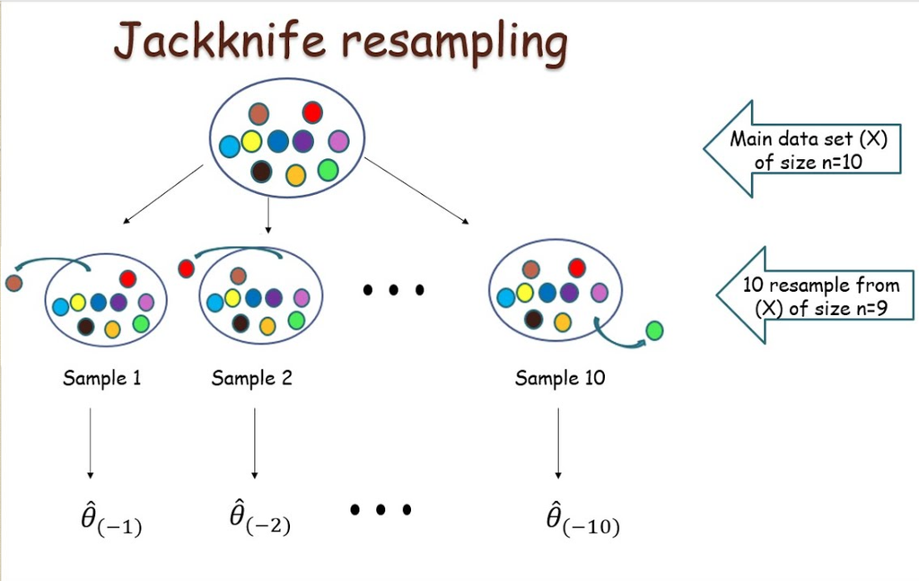

The basic idea behind the jackknife variance estimator lies in systematically recomputing the statistic estimate, leaving out one or more observations at a time from the sample set. From this new set of replicates of the statistic, an estimate for the bias and an estimate for the variance of the statistic can be calculated.

For an estimator $\hat \theta$ based on an iid sample $Y_1 , . . . , Y_n$ , let $\hat \theta$ be the “leave-1-out” estimator obtained by computing $\hat \theta$ with $Y_i$ deleted from the sample. We denote the average of these “leave-1-out” estimators by $\bar \theta_1 = n^{−1} \sum_{i=1}^n \hat \theta_{[i]}$.

## Procedure

1. Given a random sample, $x = (x_1,x_2,...,x_n)$, calculate $\hat{\theta}$.
2. Let $x_{(i)}$ be the sample but with $i^{th}$ observation removed: $$ x_{(i)} = (x_1,..., x_{i-1}, x_{i+1},..., x_n) $$
3. Calculate the same statistic using the jackknife sample in step 2 to get $\hat{\theta}_{(i)}$.
4. Repeat steps 2 through 3, n times.
5. Use this estimate of the distribution of $\hat{\theta}$ to obtain the desired characteristic (eg. standard error, bias or confidence interval).

The jackknife estimate of the standard error is

$$ \hat{SE}_J(\hat{\theta}) = \sqrt{\frac{n-1}{n} \sum_{i=1}^n(\hat{\theta}_i - \bar{\theta})^2} $$

The jackknife estimate of the bias is

$$ \textrm{bias}(\theta) = (n-1) * (\bar{\theta} - \hat{\theta}) $$

## Comparison of bootstrap and jackknife

Both methods estimate the variability of a statistic from the variability of that statistic between subsamples, rather than from parametric assumptions.

- For the more general jackknife, the delete-m observations jackknife, the bootstrap can be seen as a random approximation of it.
- Bootstrap gives different results when repeated on the same data, whereas the jackknife gives exactly the same result each time.
- The jackknife, originally used for bias reduction and only estimates the variance of the point estimator. This can be enough for basic statistical inference (e.g., hypothesis testing, confidence intervals).
- The bootstrap, on the other hand, first estimates the whole distribution (of the point estimator) and then computes the variance from that. While powerful and easy, this can become highly computationally intensive.

## Q6)

Now we will consider the dataset airquality. We focus on the variable Temp.

```r
head(airquality)
```

| Ozone | Solar.R | Wind | Temp | Month | Day |
| --- | --- | --- | --- | --- | --- |
| 41 | 190 | 7.4 | 67 | 5 | 1 |
| 36 | 118 | 8.0 | 72 | 5 | 2 |
| 12 | 149 | 12.6 | 74 | 5 | 3 |
| 18 | 313 | 11.5 | 62 | 5 | 4 |
| NA | NA | 14.3 | 56 | 5 | 5 |
| 28 | NA | 14.9 | 66 | 5 | 6 |

### Kurtosis is a numerical method in statistics that measures the sharpness of the peak in the data distribution.

# $K = \frac{\frac{1}{n} \sum_{i=1}^n(x_i - \bar x)^4}{(\frac{1}{n} \sum_{i=1}^n(x_i - \bar x)^2)^{2}}$

```r
kurtosis_fnc <- function(x,i){
    n <- length(x)
    sample_krts <- mean((x[i] - mean(x[i]))^4) / var(x[i])^2
    return(sample_krts)

}
```

```r
n <- nrow(airquality)

kurtosis <- c()
sample_kurt <- kurtosis_fnc(airquality$Temp)

for(i in 1:n){

    kurtosis[i] <- kurtosis_fnc(airquality$Temp[-i])
}

est_kurt <- mean(kurtosis)
se_kurt <- sqrt((n-1) * mean((sample_kurt - mean(kurtosis))^2))
bias_kurt <- (n-1) * (est_kurt - sample_kurt)



result <- c(sample_kurt, est_kurt, se_kurt, bias_kurt)
names(result) <- c("sample", "estimated", "std.error","bias")
result
```

**sample**

2.5371071278428

**estimated**

2.53694038501704

**std.error**

0.0020557436200316

**bias**

-0.0253449095156739

```r
library(boot)

obj <- boot(data=airquality$Temp, statistic = kurtosis_fnc, R=1000)
obj
```

```
ORDINARY NONPARAMETRIC BOOTSTRAP


Call:
boot(data = airquality$Temp, statistic = kurtosis_fnc, R = 1000)


Bootstrap Statistics :
    original     bias    std. error
t1* 2.537107 0.01955543   0.2269574
```

```r
library(bootstrap)

jack <- jackknife(airquality$Temp, kurtosis_fnc)

cat("estimate for kurtosis is:", mean(jack$jack.values), "\n","se is:", jack$jack.se,
   "\n","bias is:", jack$jack.bias)
```

```
estimate for kurtosis is: 2.53694
 se is: 0.2148629
 bias is: -0.02534491
```

## Cross Validation and Model Selection

Cross validation is a data partitioning method that can be used to assess the stability of parameter estimates, the accuracy of a classification algorithm, the adequacy of a fitted model, and in many other applications. The jackknife could be considered a special case of cross validation, because it is primarily used to estimate bias and standard error of an estimator.

In building a classifier, a researcher can partition the data into training and test sets. The model is estimated using the data in the training set only, and the misclassification rate is estimated by running the classifier on the test set.

Another version of cross validation is the “n-fold” cross validation, which partitions the data into n test sets (now test points). This “leave-one-out” procedure is like the jackknife. The data could be divided into any number K partitions, so that there are K test sets. Then the model fitting leaves out one test set in turn, so that the models are fitted K times.

Note: There are several steps to model selection, but we will focus on the prediction error. The prediction error can be estimated by cross validation, without making strong distributional assumptions about the error variable.

Steps to follow:

1. Remove $𝑘^{𝑡ℎ}$ 𝑘 = 1, ..., 𝑛 observation in order to be the test point, then fit a model with 𝑛 − 1 observation, $(𝑥_𝑖, 𝑦_𝑖)$, 𝑖 ≠ 𝑘.
1. Compute the predicted response $𝑦_𝑘̂ = 𝛽_0̂ + 𝛽_1̂ 𝑥_{1𝑘} + ... + 𝛽_𝑝̂ 𝑥_{𝑝𝑘}$
1. Compute the predicton error $𝑒_𝑘 = 𝑦_𝑘 − 𝑦_𝑘̂$
2. Estimate the mean of the squared errors $\hat \sigma^2_{\epsilon}= \frac{1}{n} \sum_{k=1}^n e^2_k$

## Q7)

For this question, ‘airquality’ dataset, get "Ozone","Solar.R","Wind", "Temp" variables.

Use ‘Ozone’ as response variable, and in order to estimate ‘Ozone’ use "Solar.R","Wind", "Temp".

Apply Leave-one-out Cross Validation technique to find the best model among 5 models below;

```r
head(airquality)
```

| Ozone | Solar.R | Wind | Temp | Month | Day |
| --- | --- | --- | --- | --- | --- |
| 41 | 190 | 7.4 | 67 | 5 | 1 |
| 36 | 118 | 8.0 | 72 | 5 | 2 |
| 12 | 149 | 12.6 | 74 | 5 | 3 |
| 18 | 313 | 11.5 | 62 | 5 | 4 |
| NA | NA | 14.3 | 56 | 5 | 5 |
| 28 | NA | 14.9 | 66 | 5 | 6 |

```r
data <- airquality[,c("Ozone","Solar.R","Wind", "Temp")]
data <- as.data.frame(scale(data))
data <- na.omit(data)
head(data)
```

|  | Ozone | Solar.R | Wind | Temp |
| --- | --- | --- | --- | --- |
| 1 | -0.03423409 | 0.04517615 | -0.7259482 | -1.1497140 |
| 2 | -0.18580489 | -0.75430487 | -0.5556388 | -0.6214670 |
| 3 | -0.91334473 | -0.41008388 | 0.7500660 | -0.4101682 |
| 4 | -0.73145977 | 1.41095624 | 0.4378323 | -1.6779609 |
| 7 | -0.57988897 | 1.25550160 | -0.3853295 | -1.3610128 |
| 8 | -0.70114561 | -0.96527903 | 1.0906847 | -1.9949091 |

## Some possible models

```r
attach(data)

models <- list(as.formula(Ozone ~ Solar.R + Wind + Temp),
               as.formula(Ozone ~  Solar.R*Wind*Temp),
               as.formula(Ozone ~ Solar.R + Wind + Temp + Wind*Temp),
               as.formula(Ozone ~ Wind + Temp + poly(Solar.R,2)),
               as.formula(Ozone ~ Wind + poly(Solar.R,2)+ poly(Temp,3)))

errors <- matrix(0, ncol = length(models), nrow = nrow(data)) #create empty matrix
colnames(errors) <- c(paste("model",1:5,sep=""))


for(i in 1:nrow(data)){
    for(j in 1:length(models)){

        model <- lm(models[[j]], data = data[-i,])
        errors[i,j] <- predict(model, data[i,]) - data$Ozone[i]
    }

}
detach(data)

comparison <- apply(errors^2,2,mean) #mean square error
comparison
```

**model1**

0.430820077177408

**model2**

0.365053207703856

**model3**

0.368029244071042

**model4**

0.435379221352885

**model5**

0.376231334540376

```r
models[[which.min(comparison)]]
```

```
Ozone ~ Solar.R * Wind * Temp
```

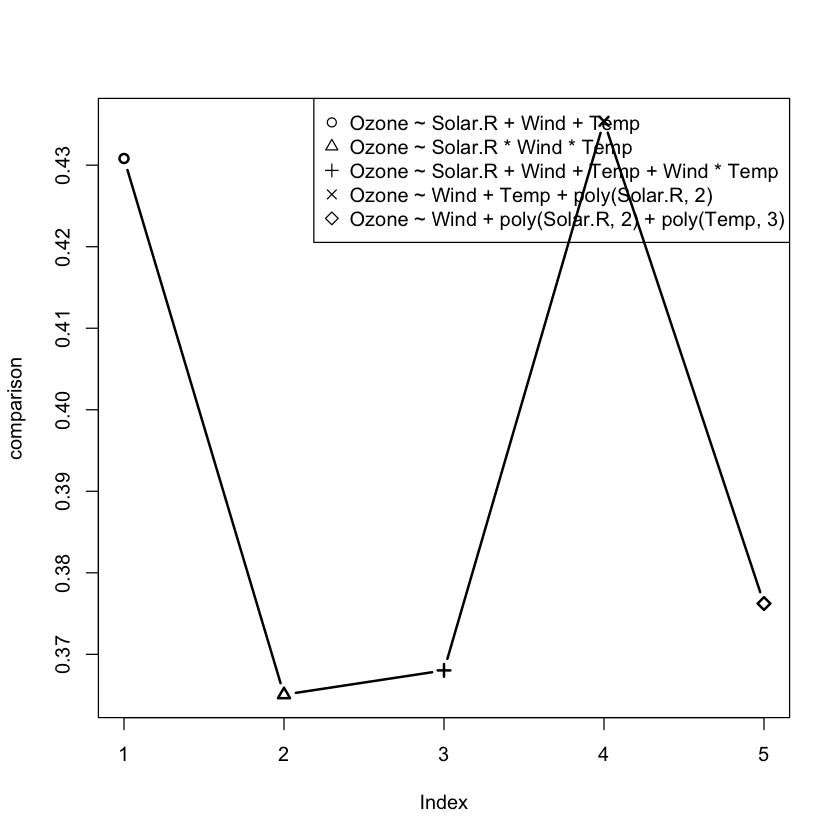

```r
plot(comparison, type = "b", lwd = 2, pch = 1:length(models))
legend("topright",legend = models, pch = 1:length(models))
```